# Predicting IDC in Breast Cancer Histology Images

🥅 The goal of this project will be to identify whether breast cancer images present with invasive ductal carcinoma or not.

## Unmet need

Accurately identifying and categorizing cancer subtypes is an important clinical task. It is not remotely straightforward and it is something that doctors don't yet fully understand.

Breast cancer is the most common form of cancer in women, and invasive ductal carcinoma (IDC) is the most common form of breast cancer (80% in women, 90% in men).

So, if automated methods can be used to save time and reduce error, it's worth our attention.

## The dataset

The dataset consists of approximately 5,000 50x50 pixel RGB digital images of H&E stained breast cancer histopathology samples that are labeled as either IDC (1) or non-IDC (0).

```python
definitions = {
    'histology': 'study of biological tissues at the microscopic level',
    'histopathology': 'diagnosis of diseases of biological tissues',
    'H&E staining': 'histological purpley pinkey staining'
}
```

H&E Stain is the most common method of cell pathology. Think of the H&E stain as a triage stain. It is used as an initial screening.

These images are small patches extracted from much larger digital images of breast tissue samples. The breast tissue contains many cells but only some of them are cancerous.

Let's check out the data. 🔥🔥🔥

```python
X = np.load('data/X.npy')
Y = np.load('data/Y.npy')
print(f'The shape of X is: {X.shape}; \t RGB')
print(f'The shape of Y is: {Y.shape}; \t\t Binary')
```

```
The shape of X is: (5547, 50, 50, 3); 	 RGB
The shape of Y is: (5547,); 		 Binary
```

The top row is negative for IDC, the bottom row is positive

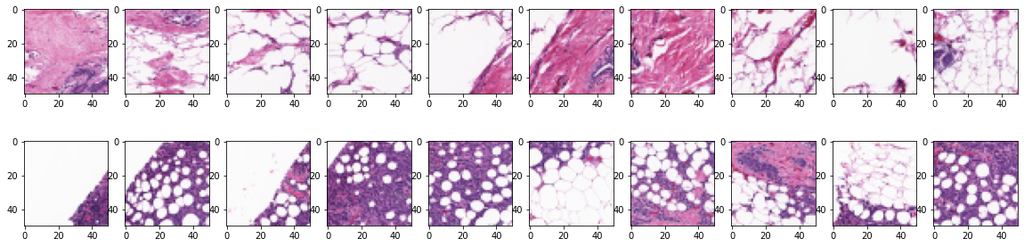

```python
neg = X[Y==0]
pos = X[Y==1]

n = 10
plt.figure(figsize = (20, 5))
for i in range(n):
    plt.subplot(2, n, i + 1)
    plt.imshow(neg[i])
    plt.subplot(2, n, n + i + 1)
    plt.imshow(pos[i])
```

You can see the pinks and the purples doing different things. Your immediate reaction might be to guess that the ratio of pink to purple is obviously the differentiating factor here. Let's take a look at some other samples.

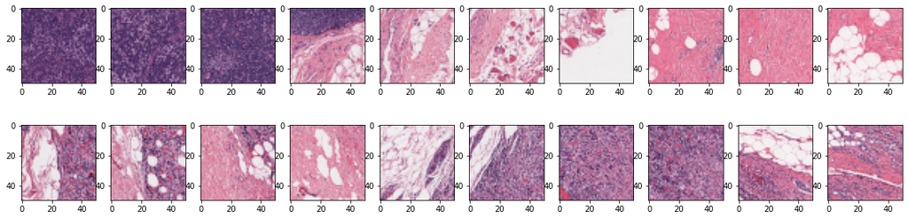

```python
n=10
plt.figure(figsize=(20,5))
for i in range(n):
    plt.subplot(2,n,i+1)
    plt.imshow(neg[i+1000])
    plt.subplot(2,n,n+i+1)
    plt.imshow(pos[i+1000])
```

A look at a different set of 10 samples each shows that the dilineation is not so obvious, especially to us unqualified, unseemly laypeople.

## This project is a good idea

There is an accompanying scientific paper discussing the dataset, which itself comes courtesy of the Cleveland Clinic Cancer Center, along with 200,000 more images which will require only minimal preprocessing. I have also requested access to a second H&E stain IDC histology dataset that I hope to retest the robustness of the final model on.

My hope is that a Deep Learning model will yield accuracy of around 80%, an entirely arbitrary number that is based on no data, just kidding i have links to a few papers that demonstrate this to be a reasonable goal. Perhaps Recall (True Positives vs False Negatives) is a more appropriate metric